[Home](http://localhost:1313/)

12 min

# TP - Machine Learning

## 1. The datasets

```python
import numpy as np
import matplotlib.pyplot as plt
```

```python
nb_sample = 127
X = np.load("CIFAR_3/X_cifar.npy")
y = np.load("CIFAR_3/y_cifar.npy")
X_gray = np.load("CIFAR_3/X_cifar_grayscale.npy")
print(np.shape(X))
```

```
(18000, 32, 32, 3)
```

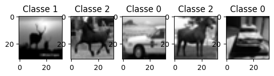

```python
for i in range(5):
    plt.subplot(1,5,i+1)
    plt.imshow(X_gray[nb_sample+i],cmap="gray")
    plt.title(f"Classe {y[nb_sample+i]}")
plt.show()
```

```python
from sklearn.model_selection import train_test_split
```

```
[4780. 4826. 4794.]
[1220. 1174. 1206.]
```

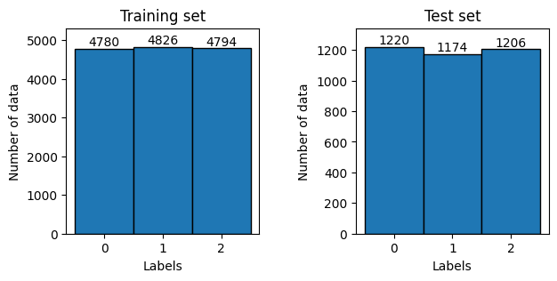

```python
X_train, X_test, y_train, y_test = train_test_split(X_gray,y,test_size=0.20)
figure_height = 3

#Compter le nombre d'images par classe
def count_labels(y):
    nb_labels = np.max(y) + 1
    nb_data = np.zeros(nb_labels)
    for i in range(nb_labels):
        nb_data[i] = np.sum(y == i)
    return nb_data
print(count_labels(y_train))
print(count_labels(y_test))
plt.figure(figsize=(7, figure_height))
# Création de l'histogramme pour l'ensemble d'apprentissage
plt.subplot(1, 2, 1)
plt.hist(y_train, bins=np.arange(np.max(y_train) + 2) - 0.5, edgecolor='black') # np.arange(np.max(y_train) + 2) - 0.5 permet de centrer les barres
plt.xlabel('Labels')
plt.ylabel('Number of data')
plt.title('Training set')
plt.margins(y=0.10)

for i in range(3):
    plt.text(i, count_labels(y_train)[i], int(count_labels(y_train)[i]), ha='center', va='bottom')
# Création de l'histogramme pour l'ensemble de test
plt.subplot(1, 2, 2)
plt.hist(y_test, bins=np.arange(np.max(y_test) + 2) - 0.5, edgecolor='black') # np.arange(np.max(y_test) + 2) - 0.5 permet de centrer les barres
plt.xlabel('Labels')
plt.ylabel('Number of data')
plt.title('Test set')
plt.margins(y=0.10)

# ajout du nombre de données par classe
for i in range(3):
    plt.text(i, count_labels(y_test)[i], int(count_labels(y_test)[i]), ha='center', va='bottom')

# Ajout d'un espace entre les sous-graphiques
plt.subplots_adjust(wspace=0.5)
# Ajout d'un espace entre les bars et le bord de l'histogramme

# Affichage des sous-graphiques
plt.show()
```

- What are the shape of the data? What are the min and max value of the pixels? Is it better to normalize the data to work in [0,1]? Display samples from the dataset

> Shape of the datasets : (18000, 32, 32, 3) = (nb_images, height, width, dimension(=RGB)) Yes it would be better to normalize data in [0,1]
- Use the sklearn method train_test_split to split the dataset in one train set and one test set. Why this split is important in Machine Learning?

> This split is important to be able to avoid overfitting and being able to train and to test the model with enough data.
- Are the train and test sets well balanced (distribution of labels)? Why is it important for supervised Machine Learning?

> Yes they are well balanced, there is approximatively the same amount of data for each label, for the train and test datasets.

## 2. Dimensionality reduction with the PCA

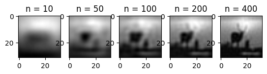

```
original shape:  (18000, 32, 32)
transformed shape:  (18000, 400)
```

```python
from sklearn.decomposition import PCA
k_list = [10, 50, 100, 200, 400]
for i,k in enumerate(k_list):
    pca = PCA(n_components=k)
    X_pca = pca.fit_transform(np.reshape(X_gray,(18000,32*32)))
    X_reconstructed = pca.inverse_transform(X_pca)
    plt.subplot(1,5,i+1)
    plt.imshow(np.reshape(X_reconstructed[nb_sample],(32,32)),cmap="gray")
    plt.title(f"n = {k}")
plt.show()


pca.explained_variance_ratio_
print("original shape: ", X_gray.shape)
print("transformed shape: ",X_pca.shape)
```

### How to find the number of Components ?

According to [jakevdp - In Depth: Principal Component Analysis](https://colab.research.google.com/github/jakevdp/PythonDataScienceHandbook/blob/master/notebooks/05.09-Principal-Component-Analysis.ipynb)

The main vector of analysis is the cumulative explained variance ratio. Cette valeur nous donne une estimation de à quelle point les valeurs influent et sont importantes. En regardant le graphique suivant, on voit qu'avec une valeur de 175, on aurait encore 95% de la variance cummulée.

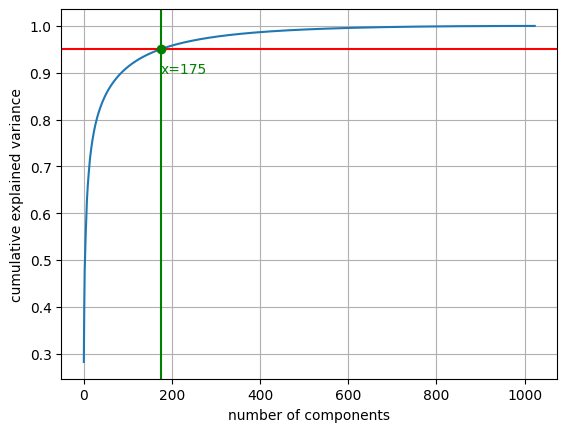

```python
pca = PCA().fit(X_gray.reshape(18000,32*32))
plt.plot(np.cumsum(pca.explained_variance_ratio_))
plt.axhline(y=0.95, color='r', linestyle='-')
x = np.argmax(np.cumsum(pca.explained_variance_ratio_) >= 0.95) + 1
plt.axvline(x=x, color='g', linestyle='-')
plt.plot(x, 0.95, 'go')
plt.text(x, 0.90, f"x={x}", color='g')
plt.xlabel('number of components')
plt.ylabel('cumulative explained variance')
plt.grid()
plt.show()
```

## 3. Supervised Machine Learning

### 3.1 Logistic Regression & Gaussian Naïve Bayes Classifier

Objectives

The main objective is to perform a supervised classification task using two classical methods:

- (multiclass) Logistic Regression.
- Gaussian Naïve Bayes Classifier. Apply these two methods on CIFAR-3-GRAY and on a compressed version of CIFAR-3-GRAY you obtained thanks to the CPA in the previous section.

**Naïve Bayes**: It is a probabilistic classifier based on Bayes' theorem. It assumes that the features are conditionally independent given the class label, which is why it is called "naïve."

**Logistic Regression**: Despite its name, logistic regression is a linear model for binary classification. It models the probability of an instance belonging to a particular class using the logistic function.

The major difference when predicting objects in images is that Logistic Regression can handle the complex relationships and dependencies between pixel values, making it more suitable for image data, while Naïve Bayes assumes independence between features, which may not align well with the correlated nature of pixel values in images

```python
from sklearn.linear_model import LogisticRegression
from sklearn.naive_bayes import GaussianNB
from sklearn.metrics import confusion_matrix
```

```python
X_train, X_test, y_train, y_test = train_test_split(X_gray,y,test_size=0.20)
pca = PCA(n_components=175)
X_pca = pca.fit_transform(np.reshape(X_gray,(18000,32*32)))

X_train_pca, X_test_pca, y_train_pca, y_test_pca = train_test_split(X_pca,y,test_size=0.20)

X_train = np.reshape(X_train,(14400,32*32))/255
X_test = np.reshape(X_test,(3600,32*32))/255
```

[output not shown]

```python
clf = [LogisticRegression(C=10**(-i)) for i in range(11)]
for i in range(11):
    clf[i].fit(X_train, y_train)


clf2 = [GaussianNB(var_smoothing=10**(-i)) for i in range(11)]
for i in range(11):
    clf2[i].fit(X_train, y_train)

clf_pca = [LogisticRegression(C=10**(-i)) for i in range(11)]
for i in range(11):
    clf_pca[i].fit(X_train_pca, y_train_pca)



clf2_pca = [GaussianNB(var_smoothing=10**(-i)) for i in range(11)]
for i in range(11):
    clf2_pca[i].fit(X_train_pca, y_train_pca)

print(clf2_pca)
```

[output not shown]

```python
for i in range(11):
    lr_predict = clf[i].predict(X_test)
    print(f"Logistic Regression's score with C = {10**(-i)}: {clf[i].score(X_test, y_test)}")

for i in range(11):
    nb_predict = clf2[i].predict(X_test)
    print(f"GaussianNB with var_smooth = {10**(-i)} : {clf2[i].score(X_test, y_test)}")

for i in range(11):
    lr_predict_pca = clf_pca[i].predict(X_test_pca)
    print(f"PCA Logistic Regression's score with C = {10**(-i)}: {clf_pca[i].score(X_test_pca, y_test_pca)}")

#nb_predict_pca = clf2_pca.predict(X_test_pca)
#print("PCA GaussianNB's score :", clf2_pca.score(X_test_pca, y_test_pca))


for i in range(11):
    clf2_pca[i].predict(X_test_pca)
    print(f"GaussianNB PCA with var_smooth = {10**(-i)} : {clf2_pca[i].score(X_test_pca, y_test_pca)}")

lr_confusion_matrix = confusion_matrix(y_test, lr_predict)
nb_confusion_matrix = confusion_matrix(y_test, nb_predict)

print(lr_confusion_matrix)
print(nb_confusion_matrix)
```

```
Logistic Regression's score with C = 1: 0.595
Logistic Regression's score with C = 0.1: 0.6019444444444444
Logistic Regression's score with C = 0.01: 0.6127777777777778
Logistic Regression's score with C = 0.001: 0.61
Logistic Regression's score with C = 0.0001: 0.5813888888888888
Logistic Regression's score with C = 1e-05: 0.5297222222222222
Logistic Regression's score with C = 1e-06: 0.47694444444444445
Logistic Regression's score with C = 1e-07: 0.39861111111111114
Logistic Regression's score with C = 1e-08: 0.32472222222222225
Logistic Regression's score with C = 1e-09: 0.32472222222222225
Logistic Regression's score with C = 1e-10: 0.32472222222222225
GaussianNB with var_smooth = 1 : 0.4313888888888889
GaussianNB with var_smooth = 0.1 : 0.5486111111111112
GaussianNB with var_smooth = 0.01 : 0.5797222222222222
GaussianNB with var_smooth = 0.001 : 0.5825
GaussianNB with var_smooth = 0.0001 : 0.5830555555555555
GaussianNB with var_smooth = 1e-05 : 0.5830555555555555
GaussianNB with var_smooth = 1e-06 : 0.5830555555555555
GaussianNB with var_smooth = 1e-07 : 0.5830555555555555
GaussianNB with var_smooth = 1e-08 : 0.5830555555555555
GaussianNB with var_smooth = 1e-09 : 0.5830555555555555
GaussianNB with var_smooth = 1e-10 : 0.5830555555555555
PCA Logistic Regression's score with C = 1: 0.6055555555555555
PCA Logistic Regression's score with C = 0.1: 0.6055555555555555
PCA Logistic Regression's score with C = 0.01: 0.6058333333333333
PCA Logistic Regression's score with C = 0.001: 0.6055555555555555
PCA Logistic Regression's score with C = 0.0001: 0.6055555555555555
PCA Logistic Regression's score with C = 1e-05: 0.6055555555555555
PCA Logistic Regression's score with C = 1e-06: 0.6052777777777778
PCA Logistic Regression's score with C = 1e-07: 0.6077777777777778
PCA Logistic Regression's score with C = 1e-08: 0.6
PCA Logistic Regression's score with C = 1e-09: 0.5669444444444445
PCA Logistic Regression's score with C = 1e-10: 0.5102777777777778
GaussianNB PCA with var_smooth = 1 : 0.37444444444444447
GaussianNB PCA with var_smooth = 0.1 : 0.36083333333333334
GaussianNB PCA with var_smooth = 0.01 : 0.40305555555555556
GaussianNB PCA with var_smooth = 0.001 : 0.5677777777777778
GaussianNB PCA with var_smooth = 0.0001 : 0.6119444444444444
GaussianNB PCA with var_smooth = 1e-05 : 0.6147222222222222
GaussianNB PCA with var_smooth = 1e-06 : 0.6158333333333333
GaussianNB PCA with var_smooth = 1e-07 : 0.6158333333333333
GaussianNB PCA with var_smooth = 1e-08 : 0.6158333333333333
GaussianNB PCA with var_smooth = 1e-09 : 0.6158333333333333
GaussianNB PCA with var_smooth = 1e-10 : 0.6158333333333333
[[1169    0    0]
 [1179    0    0]
 [1252    0    0]]
[[748 300 121]
 [137 862 180]
 [271 492 489]]
```

```python
lr_confusion_matrix = confusion_matrix(y_test, lr_predict)
nb_confusion_matrix = confusion_matrix(y_test, nb_predict)

print(lr_confusion_matrix)
print(nb_confusion_matrix)
```

### 3.2 Deep Learning / Multilayer Perceptron (MLP)

- What is the size of the input tensor? What is the size of the output layer?
- How many epochs do you use? What does it mean? What is the batch_size? What does it means?
- Why do we need to define a validation set?
- Pick the most important hyper-parameters you have to set to run the training process (e.g., optimizer…). Briefly explain why are they important (i.e. their influence).
- Comment the training results.
- Is there any overfitting? Why? If yes, what could be the causes? How to fix this issue? If you do not observe overfitting, how can you make your model overfit? Try and demonstrate the overfitting.
- According to this first performance, change the architecture of the MLP (change parameters, add/remove layers…) as well as hyper-parameters, explain why, what are the influence on the results…?

```python
X_train, X_test, y_train, y_test = train_test_split(X_gray,y,test_size=0.20)
X_train_colored, X_test_colored, y_train_colored, y_test_colored = train_test_split(X,y,test_size=0.20)

X_train = np.reshape(X_train,(14400,32*32))/255
X_test = np.reshape(X_test,(3600,32*32))/255
```

```python
import tensorflow as tf
```

```
WARNING:tensorflow:From c:\Users\nonob\AppData\Local\Programs\Python\Python311\Lib\site-packages\keras\src\losses.py:2976: The name tf.losses.sparse_softmax_cross_entropy is deprecated. Please use tf.compat.v1.losses.sparse_softmax_cross_entropy instead.
```

```python
model = tf.keras.models.Sequential([
    tf.keras.layers.Dense(123, activation='relu', input_shape=(1024,)),
    tf.keras.layers.Dropout(0.25),
    tf.keras.layers.Dense(150, activation='relu'),
    tf.keras.layers.Dropout(0.25),
    tf.keras.layers.Dense(3, activation='softmax'),
    ])
print(model.summary())
```

[output not shown]

```python
model.compile(optimizer='adam',
                loss='sparse_categorical_crossentropy',
                metrics=['accuracy'])

modele_hist = model.fit(X_train, y_train, epochs=30, batch_size=32, verbose=1, validation_data=(X_test, y_test))
```

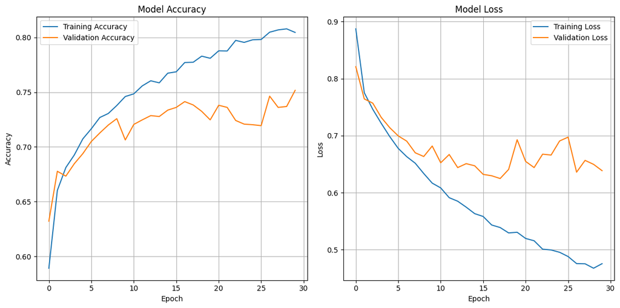

```python
plt.figure(figsize=(12, 6))

plt.subplot(1, 2, 1)
plt.plot(modele_hist.history['accuracy'], label='Training Accuracy')
plt.plot(modele_hist.history['val_accuracy'], label='Validation Accuracy')
plt.title('Model Accuracy')
plt.xlabel('Epoch')
plt.ylabel('Accuracy')
plt.legend()
plt.grid()
# Plotting loss
plt.subplot(1, 2, 2)
plt.plot(modele_hist.history['loss'], label='Training Loss')
plt.plot(modele_hist.history['val_loss'], label='Validation Loss')
plt.title('Model Loss')
plt.xlabel('Epoch')
plt.ylabel('Loss')
plt.legend()
plt.grid()

plt.tight_layout()  # Adjust layout for better spacing
plt.show()
```

### 3.3. Deep Learning / CONVOLUTIONNAL NEURAL NETWORK (CNN)

Same as before: but now we use the color images and process a Convolutional Neural Network (CNN).

```python
model_CNN = tf.keras.models.Sequential()
model_CNN.add(tf.keras.layers.Conv2D(32, (3, 3), activation='relu', input_shape=(32, 32, 3)))
model_CNN.add(tf.keras.layers.MaxPooling2D((2, 2)))
model_CNN.add(tf.keras.layers.Conv2D(64, (3, 3), activation='relu'))
model_CNN.add(tf.keras.layers.MaxPooling2D((2, 2)))
model_CNN.add(tf.keras.layers.Conv2D(64, (3, 3), activation='relu'))

model_CNN.add(tf.keras.layers.Flatten())
model_CNN.add(tf.keras.layers.Dense(64, activation='relu'))
model_CNN.add(tf.keras.layers.Dense(3))

model_CNN.summary()
```

```
Model: "sequential_6"
_________________________________________________________________
 Layer (type)                Output Shape              Param #
=================================================================
 conv2d_3 (Conv2D)           (None, 30, 30, 32)        896

 max_pooling2d_2 (MaxPoolin  (None, 15, 15, 32)        0
 g2D)

 conv2d_4 (Conv2D)           (None, 13, 13, 64)        18496

 max_pooling2d_3 (MaxPoolin  (None, 6, 6, 64)          0
 g2D)

 conv2d_5 (Conv2D)           (None, 4, 4, 64)          36928

 flatten_1 (Flatten)         (None, 1024)              0

 dense_18 (Dense)            (None, 64)                65600

 dense_19 (Dense)            (None, 3)                 195

=================================================================
Total params: 122115 (477.01 KB)
Trainable params: 122115 (477.01 KB)
Non-trainable params: 0 (0.00 Byte)
_________________________________________________________________
```

```python
model_CNN.compile(optimizer='adam',
              loss=tf.keras.losses.SparseCategoricalCrossentropy(from_logits=True),
              metrics=['accuracy'])

history = model_CNN.fit(X_train_colored, y_train, epochs=10,
                    validation_data=(X_test_colored, y_test))
```

[figure not shown]

```python
plt.figure(figsize=(12, 6))

plt.subplot(1, 2, 1)
plt.plot(history.history['accuracy'], label='Training Accuracy')
plt.plot(history.history['val_accuracy'], label='Validation Accuracy')
plt.title('Model Accuracy')
plt.xlabel('Epoch')
plt.ylabel('Accuracy')
plt.legend()
plt.grid()
# Plotting loss
plt.subplot(1, 2, 2)
plt.plot(history.history['loss'], label='Training Loss')
plt.plot(history.history['val_loss'], label='Validation Loss')
plt.title('Model Loss')
plt.xlabel('Epoch')
plt.ylabel('Loss')
plt.legend()
plt.grid()

plt.tight_layout()  # Adjust layout for better spacing
plt.show()
```